# Google Data Abalytics Capstone

Noah Borquaye

2024-02-27

### CASE STUDY: How does a bike-share navigate Speedy success?

The director of a marketing company belies the company’s future success depends on maximizing the number of annual memberships. Therefore, you and your team wants to understand how casual riders and annual members use Cyclistic’s bikes differently. From these insights, your team will design a new marketing strategy to convert casual riders into annual members. Cyclistic executives must approve your recommendations, so they must be backed up with compelling data insights and professional data visualizations.

### How Casual Riders and Annual Members Use Cyclistic’s Bikes Differently

#### Data Source and description

The data is a public dataset shared as part of the Google Data Analytics Professional Certificate program. Click [here](https://divvy-tripdata.s3.amazonaws.com/index.html) to access the data and the description. I selected the relevant columns for the purpose of this work.

#Reading the data#

```r
bike_data <- read.csv("202201-divvy-tripdata.csv")
head(bike_data)
```

```
##            ride_id rideable_type          started_at            ended_at
## 1 C2F7DD78E82EC875 electric_bike 2022-01-13 11:59:47 2022-01-13 12:02:44
## 2 A6CF8980A652D272 electric_bike 2022-01-10 08:41:56 2022-01-10 08:46:17
## 3 BD0F91DFF741C66D  classic_bike 2022-01-25 04:53:40 2022-01-25 04:58:01
## 4 CBB80ED419105406  classic_bike 2022-01-04 00:18:04 2022-01-04 00:33:00
## 5 DDC963BFDDA51EEA  classic_bike 2022-01-20 01:31:10 2022-01-20 01:37:12
## 6 A39C6F6CC0586C0B  classic_bike 2022-01-11 18:48:09 2022-01-11 18:51:31
##              start_station_name start_station_id              end_station_name
## 1      Glenwood Ave & Touhy Ave              525          Clark St & Touhy Ave
## 2      Glenwood Ave & Touhy Ave              525          Clark St & Touhy Ave
## 3 Sheffield Ave & Fullerton Ave     TA1306000016 Greenview Ave & Fullerton Ave
## 4      Clark St & Bryn Mawr Ave     KA1504000151     Paulina St & Montrose Ave
## 5   Michigan Ave & Jackson Blvd     TA1309000002        State St & Randolph St
## 6         Wood St & Chicago Ave              637       Honore St & Division St
##   end_station_id start_lat start_lng  end_lat   end_lng member_casual
## 1         RP-007  42.01280 -87.66591 42.01256 -87.67437        casual
## 2         RP-007  42.01276 -87.66597 42.01256 -87.67437        casual
## 3   TA1307000001  41.92560 -87.65371 41.92533 -87.66580        member
## 4   TA1309000021  41.98359 -87.66915 41.96151 -87.67139        casual
## 5   TA1305000029  41.87785 -87.62408 41.88462 -87.62783        member
## 6   TA1305000034  41.89563 -87.67207 41.90312 -87.67394        member
```

#checking the data structure#

```r
str(bike_data)
```

```
## 'data.frame':    103770 obs. of  13 variables:
##  $ ride_id           : chr  "C2F7DD78E82EC875" "A6CF8980A652D272" "BD0F91DFF741C66D" "CBB80ED419105406" ...
##  $ rideable_type     : chr  "electric_bike" "electric_bike" "classic_bike" "classic_bike" ...
##  $ started_at        : chr  "2022-01-13 11:59:47" "2022-01-10 08:41:56" "2022-01-25 04:53:40" "2022-01-04 00:18:04" ...
##  $ ended_at          : chr  "2022-01-13 12:02:44" "2022-01-10 08:46:17" "2022-01-25 04:58:01" "2022-01-04 00:33:00" ...
##  $ start_station_name: chr  "Glenwood Ave & Touhy Ave" "Glenwood Ave & Touhy Ave" "Sheffield Ave & Fullerton Ave" "Clark St & Bryn Mawr Ave" ...
##  $ start_station_id  : chr  "525" "525" "TA1306000016" "KA1504000151" ...
##  $ end_station_name  : chr  "Clark St & Touhy Ave" "Clark St & Touhy Ave" "Greenview Ave & Fullerton Ave" "Paulina St & Montrose Ave" ...
##  $ end_station_id    : chr  "RP-007" "RP-007" "TA1307000001" "TA1309000021" ...
##  $ start_lat         : num  42 42 41.9 42 41.9 ...
##  $ start_lng         : num  -87.7 -87.7 -87.7 -87.7 -87.6 ...
##  $ end_lat           : num  42 42 41.9 42 41.9 ...
##  $ end_lng           : num  -87.7 -87.7 -87.7 -87.7 -87.6 ...
##  $ member_casual     : chr  "casual" "casual" "member" "casual" ...
```

```r
colnames(bike_data)
```

```
##  [1] "ride_id"            "rideable_type"      "started_at"
##  [4] "ended_at"           "start_station_name" "start_station_id"
##  [7] "end_station_name"   "end_station_id"     "start_lat"
## [10] "start_lng"          "end_lat"            "end_lng"
## [13] "member_casual"
```

#Selecting relevant columns and removing missing values#

```r
library(dplyr)
bike_df <- bike_data %>%
  select(ride_id,rideable_type, started_at, ended_at, start_station_name,   end_station_name,   member_casual) %>%
  na.omit()
```

```r
 sum(is.na(bike_df))
```

```
## [1] 0
```

#Checking data types and formatting#

```r
library(lubridate)
new_bike_df <- bike_df %>%
  mutate(started_at = as.POSIXct(started_at, format = "%Y-%m-%d %H:%M:%S")) %>%
  mutate(ended_at = as.POSIXct(ended_at, format = "%Y-%m-%d %H:%M:%S")) %>%
  mutate(trip_duration = as.numeric(difftime(ended_at, started_at, units =  "mins")))
```

#Data Aggregation#

```r
new_bike_df %>%
  count(name = "Total_rides")
```

```
##   Total_rides
## 1      103770
```

#Number of rides made by each customer type#

```r
new_bike_df %>%
  group_by(member_casual ) %>%
  count(name = "number_of_rides")
```

```
## # A tibble: 2 × 2
## # Groups:   member_casual [2]
##   member_casual number_of_rides
##   <chr>                   <int>
## 1 casual                  18520
## 2 member                  85250
```

#Number of rides made ny each bike type#

```r
new_bike_df %>%
  group_by(rideable_type) %>%
  count(name = "number_of_rides")
```

```
## # A tibble: 3 × 2
## # Groups:   rideable_type [3]
##   rideable_type number_of_rides
##   <chr>                   <int>
## 1 classic_bike            55067
## 2 docked_bike               961
## 3 electric_bike           47742
```

#Average trip duration (minutes) made with each bike type#

```r
mean_new_bike <- new_bike_df %>%
  group_by(rideable_type ) %>%
  summarise(mean_trip_duration = mean(trip_duration))%>%
  arrange(desc(mean_trip_duration))
mean_new_bike
```

```
## # A tibble: 3 × 2
##   rideable_type mean_trip_duration
##   <chr>                      <dbl>
## 1 docked_bike                223.
## 2 classic_bike                15.4
## 3 electric_bike               10.9
```

```r
new_bike_df %>%
  group_by(member_casual, rideable_type ) %>%
  count(name = "total_rideable_type") %>%
  arrange(desc(total_rideable_type))
```

```
## # A tibble: 5 × 3
## # Groups:   member_casual, rideable_type [5]
##   member_casual rideable_type total_rideable_type
##   <chr>         <chr>                       <int>
## 1 member        classic_bike                48093
## 2 member        electric_bike               37157
## 3 casual        electric_bike               10585
## 4 casual        classic_bike                 6974
## 5 casual        docked_bike                   961
```

### Visualizations

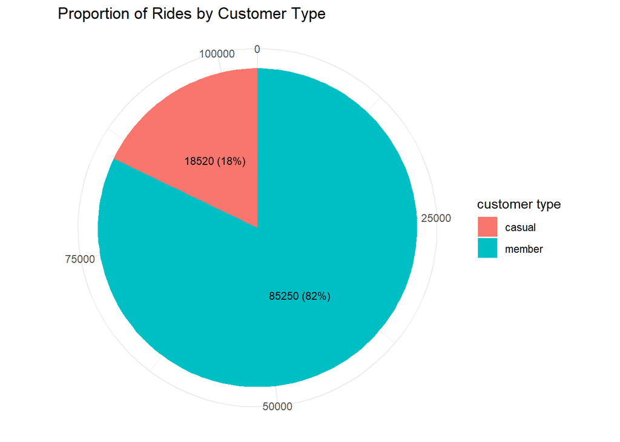

```r
library(ggplot2)
```

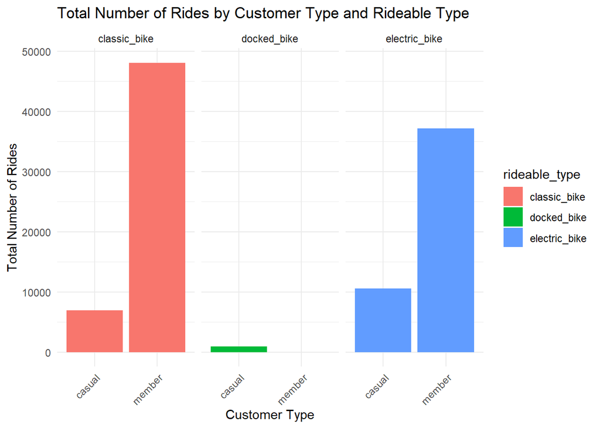

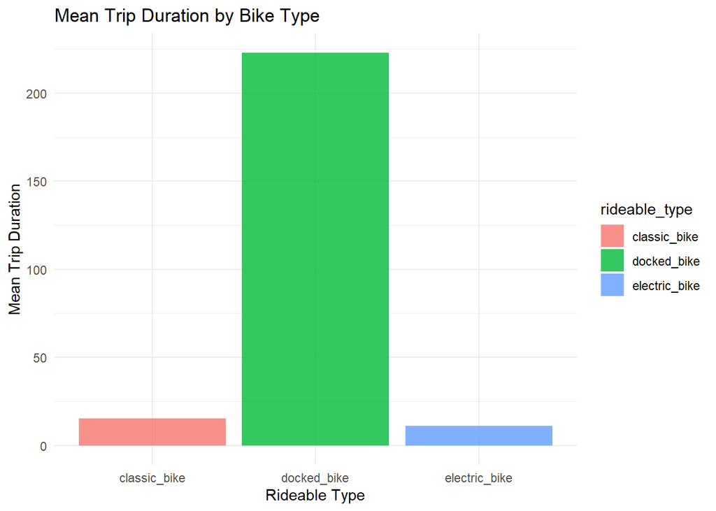

### Analysis

- 82% of the rides were made by customers who are members while 18% were made by customers who are casual.
- Docked bikes were used by casual customers only, and not often.
- Casual customers used docked bikes for long trips.